# Ashley Mersman

## Project 6

## Task1_Mersman

02/19/2023

## Task 1. Begin with the End in Mind

Read the exercise. Begin considering what you'd like your second project to focus on / showcase.

Use your second project to show all the Python things you know.

Read from a data file. Use statistics - mean, median, mode, standard deviation, variance for one or more of the numerical columns. Use built-in functions min(), max(), len(), count of records, number of columns, others... Create some custom functions, use some branching logic to transform and/or show only a part of the data. Get some of your data into a list. Use filter(), map(), and list comprehensions to clean and transform the data. Use pandas Use matplotlib hist Strive to "tell a story" with data. Use a good title section and useful section headings to professionally present your work.

## Task 2 - Diamonds Dataset

Follow the instructions for Exercise 9.16 (starting pg. 350). Complete the exercise in a notebook.

1. Load: Get the file, store it in your repo, and load it into a DataFrame.
2. View: Display the first 7 rows and the last 7 rows.
3. Describe: Use the DataFrame describe() function to calculate basic descriptive statistics for all numeric columns.
4. Series: Use the Series method describe() to calculate the descriptive stats for all category/text columns.
5. Unique: Use the Series method unique() to get unique category values.
6. Histograms: Use the DataFrame's hist() function to create a histogram for each numerical column.

Required: Use Section headings in your Markdown to make it clear that each of these sections are shown in your notebook. They should be numbered 1-5 and include the keyword shown above.

Required: Include the title of the notebook, and your name and date at the top. Do these consistently. A heading and section titles is required in every notebook.

## 1. Load the DataFrame

```python
import pandas as pd
```

```python
df=pd.read_csv("diamonds.csv", index_col=0)
```

## 2. View the last 7 and first 7 rows of DataFrame

```python
df.head(7)
```

|  | carat | cut | color | clarity | depth | table | price | x | y | z |
| --- | --- | --- | --- | --- | --- | --- | --- | --- | --- | --- |
| 1 | 0.23 | Ideal | E | SI2 | 61.5 | 55.0 | 326 | 3.95 | 3.98 | 2.43 |
| 2 | 0.21 | Premium | E | SI1 | 59.8 | 61.0 | 326 | 3.89 | 3.84 | 2.31 |
| 3 | 0.23 | Good | E | VS1 | 56.9 | 65.0 | 327 | 4.05 | 4.07 | 2.31 |
| 4 | 0.29 | Premium | I | VS2 | 62.4 | 58.0 | 334 | 4.20 | 4.23 | 2.63 |
| 5 | 0.31 | Good | J | SI2 | 63.3 | 58.0 | 335 | 4.34 | 4.35 | 2.75 |
| 6 | 0.24 | Very Good | J | VVS2 | 62.8 | 57.0 | 336 | 3.94 | 3.96 | 2.48 |
| 7 | 0.24 | Very Good | I | VVS1 | 62.3 | 57.0 | 336 | 3.95 | 3.98 | 2.47 |

```python
df.tail(7)
```

|  | carat | cut | color | clarity | depth | table | price | x | y | z |
| --- | --- | --- | --- | --- | --- | --- | --- | --- | --- | --- |
| 53934 | 0.70 | Very Good | E | VS2 | 61.2 | 59.0 | 2757 | 5.69 | 5.72 | 3.49 |
| 53935 | 0.72 | Premium | D | SI1 | 62.7 | 59.0 | 2757 | 5.69 | 5.73 | 3.58 |
| 53936 | 0.72 | Ideal | D | SI1 | 60.8 | 57.0 | 2757 | 5.75 | 5.76 | 3.50 |
| 53937 | 0.72 | Good | D | SI1 | 63.1 | 55.0 | 2757 | 5.69 | 5.75 | 3.61 |
| 53938 | 0.70 | Very Good | D | SI1 | 62.8 | 60.0 | 2757 | 5.66 | 5.68 | 3.56 |
| 53939 | 0.86 | Premium | H | SI2 | 61.0 | 58.0 | 2757 | 6.15 | 6.12 | 3.74 |
| 53940 | 0.75 | Ideal | D | SI2 | 62.2 | 55.0 | 2757 | 5.83 | 5.87 | 3.64 |

## 3 Descriptive statistics, .describe()

```python
df.describe()
```

|  | carat | depth | table | price | x | y | z |
| --- | --- | --- | --- | --- | --- | --- | --- |
| count | 53940.000000 | 53940.000000 | 53940.000000 | 53940.000000 | 53940.000000 | 53940.000000 | 53940.000000 |
| mean | 0.797940 | 61.749405 | 57.457184 | 3932.799722 | 5.731157 | 5.734526 | 3.538734 |
| std | 0.474011 | 1.432621 | 2.234491 | 3989.439738 | 1.121761 | 1.142135 | 0.705699 |
| min | 0.200000 | 43.000000 | 43.000000 | 326.000000 | 0.000000 | 0.000000 | 0.000000 |
| 25% | 0.400000 | 61.000000 | 56.000000 | 950.000000 | 4.710000 | 4.720000 | 2.910000 |
| 50% | 0.700000 | 61.800000 | 57.000000 | 2401.000000 | 5.700000 | 5.710000 | 3.530000 |
| 75% | 1.040000 | 62.500000 | 59.000000 | 5324.250000 | 6.540000 | 6.540000 | 4.040000 |
| max | 5.010000 | 79.000000 | 95.000000 | 18823.000000 | 10.740000 | 58.900000 | 31.800000 |

## 4 Series Statistics, .describe()

```python
df.carat.describe()
```

```
count    53940.000000
mean         0.797940
std          0.474011
min          0.200000
25%          0.400000
50%          0.700000
75%          1.040000
max          5.010000
Name: carat, dtype: float64
```

```python
df.depth.describe()
```

```
count    53940.000000
mean        61.749405
std          1.432621
min         43.000000
25%         61.000000
50%         61.800000
75%         62.500000
max         79.000000
Name: depth, dtype: float64
```

```python
df.table.describe()
```

```
count    53940.000000
mean        57.457184
std          2.234491
min         43.000000
25%         56.000000
50%         57.000000
75%         59.000000
max         95.000000
Name: table, dtype: float64
```

```python
df.price.describe()
```

```
count    53940.000000
mean      3932.799722
std       3989.439738
min        326.000000
25%        950.000000
50%       2401.000000
75%       5324.250000
max      18823.000000
Name: price, dtype: float64
```

```python
df.x.describe()
```

```
count    53940.000000
mean         5.731157
std          1.121761
min          0.000000
25%          4.710000
50%          5.700000
75%          6.540000
max         10.740000
Name: x, dtype: float64
```

```python
df.y.describe()
```

```
count    53940.000000
mean         5.734526
std          1.142135
min          0.000000
25%          4.720000
50%          5.710000
75%          6.540000
max         58.900000
Name: y, dtype: float64
```

```python
df.z.describe()
```

```
count    53940.000000
mean         3.538734
std          0.705699
min          0.000000
25%          2.910000
50%          3.530000
75%          4.040000
max         31.800000
Name: z, dtype: float64
```

## 5 Series.unique()

```python
df.cut.unique()
```

```
array(['Ideal', 'Premium', 'Good', 'Very Good', 'Fair'], dtype=object)
```

```python
df.color.unique()
```

```
array(['E', 'I', 'J', 'H', 'F', 'G', 'D'], dtype=object)
```

```python
df.clarity.unique()
```

```
array(['SI2', 'SI1', 'VS1', 'VS2', 'VVS2', 'VVS1', 'I1', 'IF'],
      dtype=object)
```

## 6 Histograms

```
array([[<AxesSubplot:title={'center':'carat'}>,
        <AxesSubplot:title={'center':'depth'}>,
        <AxesSubplot:title={'center':'table'}>],
       [<AxesSubplot:title={'center':'price'}>,
        <AxesSubplot:title={'center':'x'}>,
        <AxesSubplot:title={'center':'y'}>],
       [<AxesSubplot:title={'center':'z'}>, <AxesSubplot:>,
        <AxesSubplot:>]], dtype=object)
```

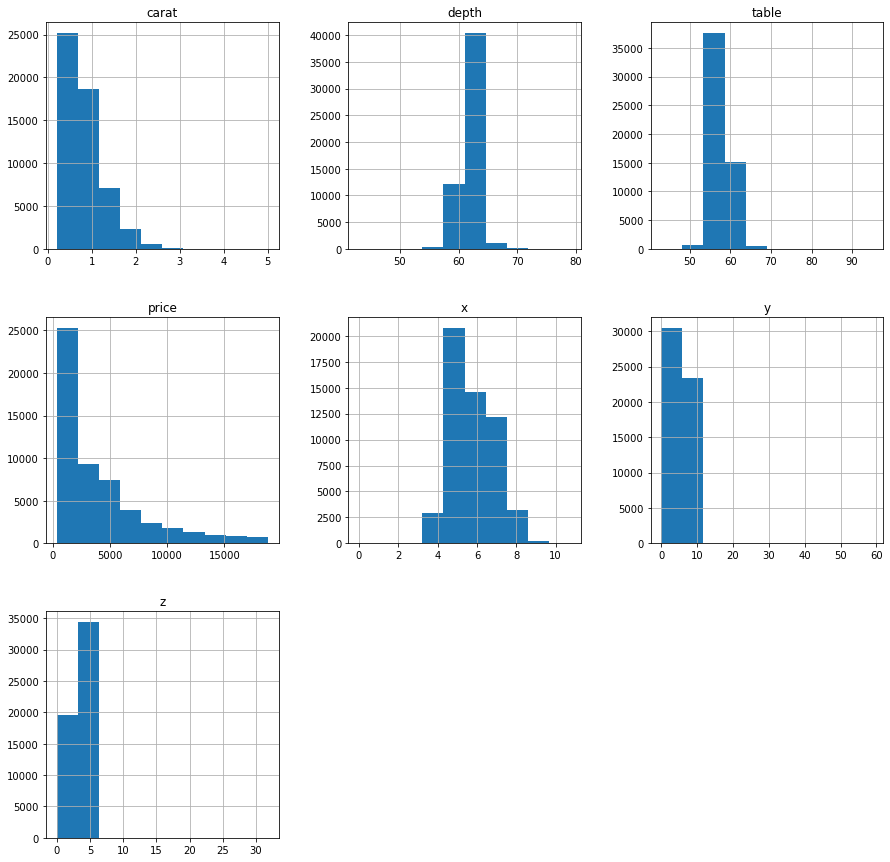

```python
df.hist(figsize=(15,15))
```